# assignment1

## Assignment 1 - Introduction to the Tidyverse

The deliverable for this assignment is a rendered HTML document. Submit your document via Canvas.

For all questions where a comment or an answer is required, be sure to type out the answer. Do not depend on the R code and output to “speak for you”. For example, if you are asked how many rows are in a dataset, do not just use a structure command and assume that the answer will be seen. Instead, please write out: “There are ___ rows”.

We will use the flights dataset that is found in the nycflights13 package. You will also need the Tidyverse package. This dataset is described in detail at: https://cran.r-project.org/web/packages/nycflights13/nycflights13.pdf. The esquisse package is also loaded if you wish to use it.

You need to install the nycflights13, tidyverse, and esquisse packages for this project if they are not already installed. Once insatlled, You will need to library them by running the code chunk below.

```r
#install.packages("nycflights13")
#install.packages("tidyverse")
#install.packages("esquisse")
library(nycflights13)
library(tidyverse)
library(esquisse)
```

Bring in the nycflights13 dataset from the nycflights13 package by using the following code. This creates a data frame called flights.

```r
flights = nycflights13::flights
```

**Question 1:** How many rows and columns are in this dataset?

- There are 336,776 rows/observations and 19 columns/variables.

**Question 2:** Use an appropriate function to create a new data frame (call the data frame “long”) that contains only the flights with a “distance” greater than 1000. How many rows and columns are in this new data frame?

```r
long = flights %>% filter(distance > 1000)
summary(long)
```

```
      year          month             day           dep_time    sched_dep_time
 Min.   :2013   Min.   : 1.000   Min.   : 1.00   Min.   :   1   Min.   : 500
 1st Qu.:2013   1st Qu.: 4.000   1st Qu.: 8.00   1st Qu.: 856   1st Qu.: 900
 Median :2013   Median : 7.000   Median :16.00   Median :1352   Median :1345
 Mean   :2013   Mean   : 6.573   Mean   :15.74   Mean   :1334   Mean   :1329
 3rd Qu.:2013   3rd Qu.:10.000   3rd Qu.:23.00   3rd Qu.:1743   3rd Qu.:1729
 Max.   :2013   Max.   :12.000   Max.   :31.00   Max.   :2400   Max.   :2359
                                                 NA's   :1784
   dep_delay          arr_time    sched_arr_time   arr_delay
 Min.   : -43.00   Min.   :   1   Min.   :   1   Min.   : -86.000
 1st Qu.:  -4.00   1st Qu.:1114   1st Qu.:1140   1st Qu.: -19.000
 Median :  -1.00   Median :1544   Median :1610   Median :  -6.000
 Mean   :  11.53   Mean   :1515   Mean   :1559   Mean   :   4.029
 3rd Qu.:   9.00   3rd Qu.:2006   3rd Qu.:2014   3rd Qu.:  12.000
 Max.   :1301.00   Max.   :2400   Max.   :2359   Max.   :1272.000
 NA's   :1784      NA's   :1923                  NA's   :2353
   carrier              flight       tailnum             origin
 Length:147105      Min.   :   1   Length:147105      Length:147105
 Class :character   1st Qu.: 375   Class :character   Class :character
 Mode  :character   Median : 884   Mode  :character   Mode  :character
                    Mean   :1169
                    3rd Qu.:1625
                    Max.   :6168

     dest              air_time        distance         hour
 Length:147105      Min.   : 93.0   Min.   :1005   Min.   : 5.00
 Class :character   1st Qu.:157.0   1st Qu.:1085   1st Qu.: 9.00
 Mode  :character   Median :203.0   Median :1428   Median :13.00
                    Mean   :231.2   Mean   :1684   Mean   :13.02
                    3rd Qu.:314.0   3rd Qu.:2425   3rd Qu.:17.00
                    Max.   :695.0   Max.   :4983   Max.   :23.00
                    NA's   :2353
     minute        time_hour
 Min.   : 0.00   Min.   :2013-01-01 05:00:00.00
 1st Qu.:10.00   1st Qu.:2013-04-04 20:00:00.00
 Median :29.00   Median :2013-07-03 23:00:00.00
 Mean   :27.12   Mean   :2013-07-03 23:55:29.21
 3rd Qu.:45.00   3rd Qu.:2013-10-02 11:00:00.00
 Max.   :59.00   Max.   :2013-12-31 23:00:00.00
```

- There are now only 147,105 rows and 19 columns.

**Question 3:** Use an appropriate function to create a new data frame (call the data frame “flightnum”) that contains only the “flight” column. How many rows and columns are in this new data frame?

```r
flightnum = flights %>% select(flight)
```

- There are 336,776 rows and only 1 column.

**Question 4:** Using the original flights data frame, what is average “air_time” of flights in the dataset? Hint: You can either use a specific function here to calculate the mean (the Tidyverse method is described here: https://dplyr.tidyverse.org/reference/summarise.html) or you can use the summary function.

```r
summary(flights)
```

```
      year          month             day           dep_time    sched_dep_time
 Min.   :2013   Min.   : 1.000   Min.   : 1.00   Min.   :   1   Min.   : 106
 1st Qu.:2013   1st Qu.: 4.000   1st Qu.: 8.00   1st Qu.: 907   1st Qu.: 906
 Median :2013   Median : 7.000   Median :16.00   Median :1401   Median :1359
 Mean   :2013   Mean   : 6.549   Mean   :15.71   Mean   :1349   Mean   :1344
 3rd Qu.:2013   3rd Qu.:10.000   3rd Qu.:23.00   3rd Qu.:1744   3rd Qu.:1729
 Max.   :2013   Max.   :12.000   Max.   :31.00   Max.   :2400   Max.   :2359
                                                 NA's   :8255
   dep_delay          arr_time    sched_arr_time   arr_delay
 Min.   : -43.00   Min.   :   1   Min.   :   1   Min.   : -86.000
 1st Qu.:  -5.00   1st Qu.:1104   1st Qu.:1124   1st Qu.: -17.000
 Median :  -2.00   Median :1535   Median :1556   Median :  -5.000
 Mean   :  12.64   Mean   :1502   Mean   :1536   Mean   :   6.895
 3rd Qu.:  11.00   3rd Qu.:1940   3rd Qu.:1945   3rd Qu.:  14.000
 Max.   :1301.00   Max.   :2400   Max.   :2359   Max.   :1272.000
 NA's   :8255      NA's   :8713                  NA's   :9430
   carrier              flight       tailnum             origin
 Length:336776      Min.   :   1   Length:336776      Length:336776
 Class :character   1st Qu.: 553   Class :character   Class :character
 Mode  :character   Median :1496   Mode  :character   Mode  :character
                    Mean   :1972
                    3rd Qu.:3465
                    Max.   :8500

     dest              air_time        distance         hour
 Length:336776      Min.   : 20.0   Min.   :  17   Min.   : 1.00
 Class :character   1st Qu.: 82.0   1st Qu.: 502   1st Qu.: 9.00
 Mode  :character   Median :129.0   Median : 872   Median :13.00
                    Mean   :150.7   Mean   :1040   Mean   :13.18
                    3rd Qu.:192.0   3rd Qu.:1389   3rd Qu.:17.00
                    Max.   :695.0   Max.   :4983   Max.   :23.00
                    NA's   :9430
     minute        time_hour
 Min.   : 0.00   Min.   :2013-01-01 05:00:00.00
 1st Qu.: 8.00   1st Qu.:2013-04-04 13:00:00.00
 Median :29.00   Median :2013-07-03 10:00:00.00
 Mean   :26.23   Mean   :2013-07-03 05:22:54.64
 3rd Qu.:44.00   3rd Qu.:2013-10-01 07:00:00.00
 Max.   :59.00   Max.   :2013-12-31 23:00:00.00
```

- the average of the air_time variable is 150.7.

Before proceeding to Question 5, create a new data frame called “JFK” that includes only flights originating at JFK. Pay close attention to how to filter a non-numeric variable. The filter function is described here: https://dplyr.tidyverse.org/reference/filter.html.

```r
JFK = flights %>% filter(origin == "JFK")
```

```r
str(JFK)
```

```
tibble [111,279 × 19] (S3: tbl_df/tbl/data.frame)
 $ year          : int [1:111279] 2013 2013 2013 2013 2013 2013 2013 2013 2013 2013 ...
 $ month         : int [1:111279] 1 1 1 1 1 1 1 1 1 1 ...
 $ day           : int [1:111279] 1 1 1 1 1 1 1 1 1 1 ...
 $ dep_time      : int [1:111279] 542 544 557 558 558 558 559 606 611 613 ...
 $ sched_dep_time: int [1:111279] 540 545 600 600 600 600 559 610 600 610 ...
 $ dep_delay     : num [1:111279] 2 -1 -3 -2 -2 -2 0 -4 11 3 ...
 $ arr_time      : int [1:111279] 923 1004 838 849 853 924 702 837 945 925 ...
 $ sched_arr_time: int [1:111279] 850 1022 846 851 856 917 706 845 931 921 ...
 $ arr_delay     : num [1:111279] 33 -18 -8 -2 -3 7 -4 -8 14 4 ...
 $ carrier       : chr [1:111279] "AA" "B6" "B6" "B6" ...
 $ flight        : int [1:111279] 1141 725 79 49 71 194 1806 1743 303 135 ...
 $ tailnum       : chr [1:111279] "N619AA" "N804JB" "N593JB" "N793JB" ...
 $ origin        : chr [1:111279] "JFK" "JFK" "JFK" "JFK" ...
 $ dest          : chr [1:111279] "MIA" "BQN" "MCO" "PBI" ...
 $ air_time      : num [1:111279] 160 183 140 149 158 345 44 128 366 175 ...
 $ distance      : num [1:111279] 1089 1576 944 1028 1005 ...
 $ hour          : num [1:111279] 5 5 6 6 6 6 5 6 6 6 ...
 $ minute        : num [1:111279] 40 45 0 0 0 0 59 10 0 10 ...
 $ time_hour     : POSIXct[1:111279], format: "2013-01-01 05:00:00" "2013-01-01 05:00:00" ...
```

**Question 5:** Create an appropriate plot of “dep_delay” for the flights originating at JFK. Comment on any pattern you might see in the data. Hint: You may find it useful to reduce the length of the x axis. How to do this is described here: https://ggplot2.tidyverse.org/reference/lims.html.

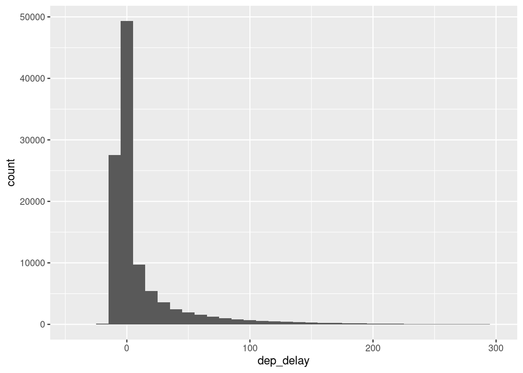

```r
ggplot(JFK, aes(x=dep_delay))+geom_histogram(binwidth = 10)+xlim(NA,300)
```

- From the histogram I can see that most flights are delayed when departing between -10 to 10 mintues. As the delay/early departure time increases the amount of flights are drastically reduced.

**Question 6:** Create an appropriate plot of “sched_dep_time” versus “dep_delay” for the flights originating at JFK. Comment on any pattern you might see in the data.

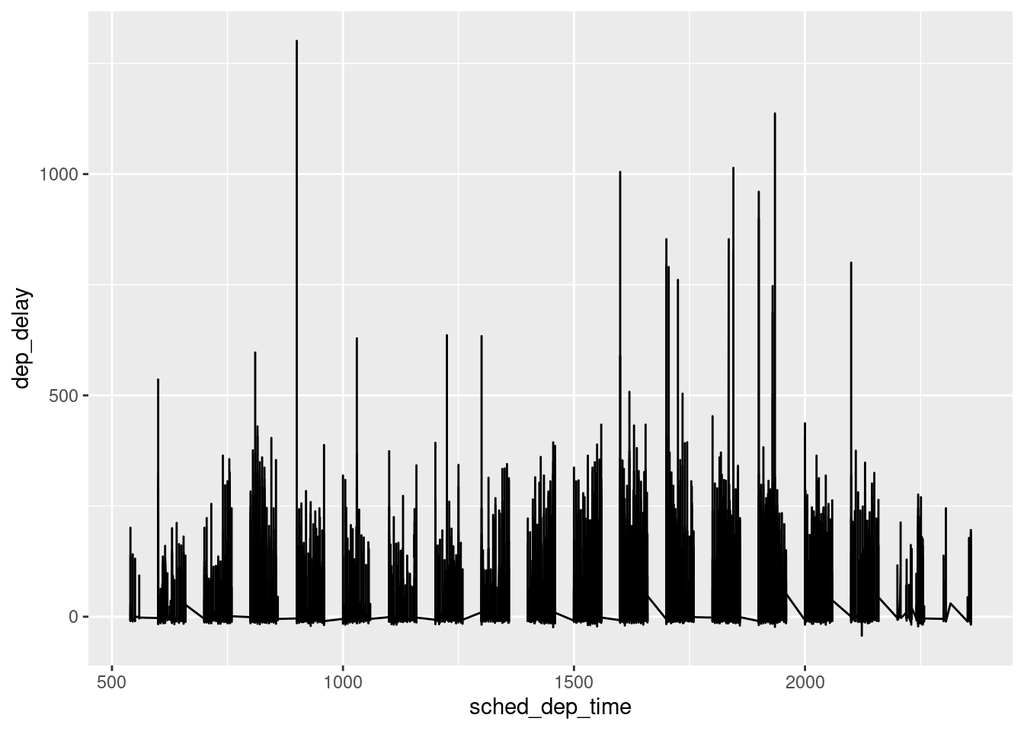

```r
ggplot(JFK, aes(x=sched_dep_time, y=dep_delay))+geom_line()
```